# The Role of Hyperoxia in Sepsis Mortality

C.V. Cosgriff, MD/MPH Student, Harvard Chan School

## Setup

```r
library(tidyverse)
library(broom)
library(lubridate)
library(stringr)
library(RPostgreSQL)
library(MIMICbook) #JRaffa's MIMIC code book
library(epitools) # For calculating OR's
library(tableone) # Generating Table 1
library(sjstats) # Some useful stats tools e.g. hoslem_gof
library(sjPlot)

# These libs are for logistic regression diagnostics
library(rms)
library(quantreg)
library(pROC)
library(separationplot)
library(heatmapFit)
# End of logistic libs

library(rstudioapi)
library(dslabs) # Dr. Irrizary's library

ds_theme_set() # Dr. Irrizary's theme

# Database access; you'll need to change 10.8.0.1 to the server you are using
# and you will also need to run ths in RStudio as I use the RStudio API to ask
# for a password. Edit this definition for your environment as need.
drv <- dbDriver("PostgreSQL")
mimic <- dbConnect(drv, dbname = "mimic", host = "10.8.0.1", port = 5432,
                   user = "mimicuser",
                   password = askForPassword("MIMIC Password: "))
```

## Cohort Design

The initial cohort table was began in sql with the following code (adapted from Alistair Johnson’s code).

```sql
SET search_path = 'mimiciii';

DROP MATERIALIZED VIEW IF EXISTS hyperoxia_sepsis_baseCohort CASCADE;
CREATE MATERIALIZED VIEW hyperoxia_sepsis_baseCohort AS

WITH icuStaysBase AS
(
SELECT icu.subject_id, icu.hadm_id, icu.icustay_id, adm.hospital_expire_flag
, EXTRACT(EPOCH FROM outtime - intime)/60.0/60.0/24.0 as icu_length_of_stay
, EXTRACT('epoch' from icu.intime - pat.dob) / 60.0 / 60.0 / 24.0 / 365.242 as age
, pat.gender, adm.ethnicity
, CASE
        WHEN adm.deathtime BETWEEN icu.intime and icu.outtime
            THEN 1
        -- sometimes there are typographical errors in the death date, so check before intime
        WHEN adm.deathtime <= icu.intime
            THEN 1
        WHEN adm.dischtime <= icu.outtime
            AND adm.discharge_location = 'DEAD/EXPIRED'
            THEN 1
        ELSE 0
        END AS icustay_expire_flag

FROM icustays icu
INNER JOIN patients pat /* Inner join because we only need patients who had an ICU stay */
  ON icu.subject_id = pat.subject_id
INNER JOIN admissions adm /* Inner join because we only care about admissions which have an ICU stay */
    ON icu.hadm_id = adm.hadm_id
)
, ventDurations AS
(
SELECT vd.icustay_id, vd.duration_hours
FROM ventdurations vd
)
, oasisscore AS
(
SELECT oa.icustay_id, oa.oasis
FROM oasis oa
)
, elixhauser AS
(
SELECT el.hadm_id,
    el.elixhauser_vanwalraven AS score
    FROM elixhauser_quan_score el
)
SELECT b.*, vd.duration_hours AS vent_dur, s.angus
, CASE
    WHEN b.icu_length_of_stay <= 0.1666667 THEN 1
    ELSE 0 END
    AS exclusion_los
, CASE
    WHEN b.age < 16 then 1
    ELSE 0 END
    AS exclude_age
, el.score AS elixhauser, oa.oasis
, CASE
    WHEN (SELECT count(vpd.icustay_id) FROM vasopressordurations vpd WHERE b.icustay_id = vpd.icustay_id AND vpd.duration_hours > 0) > 0 THEN 1
    ELSE 0 END
    AS vasopressor_flag
FROM icuStaysBase b
INNER JOIN oasis oa on b.icustay_id = oa.icustay_id
INNER JOIN elixhauser el on b.hadm_id = el.hadm_id
INNER JOIN ventDurations vd ON b.icustay_id = vd.icustay_id /* Our cohort it will only include people who were ventilated */
INNER JOIN angus_sepsis s on b.hadm_id = s.hadm_id;
```

Next, the base cohort can be pulled from the database.

```r
cohort.df <- dbGetQuery(mimic,
                        "SELECT * FROM mimiciii.hyperoxia_sepsis_baseCohort")
```

This cohort contains all of the ICU stays for which ventilation data existed and each row actually corresponds to a ventilation duration recording. We will now build the subject cohort that will eventually be used for analysis and as we go we will tidy the data.

Before we begin inclusion/exclusion, lets do some very basic cleaning.

There are ages of 300 in the dataset because of HIPPA, so we set them to the median of that group per MIT LCP.

```r
cohort.df$age[cohort.df$age>100] <- 91.4
```

Lets also recode ethnicity since there are too many groups based on the MIMIC ethnicities.

```r
ethnicities <- c("WHITE", "BLACK", "HISPANIC", "ASIAN")

for (i in 1:length(ethnicities)) {
  cohort.df$ethnicity[str_detect(cohort.df$ethnicity, ethnicities[i])] <- ethnicities[i]
}
cohort.df$ethnicity[!(cohort.df$ethnicity %in% ethnicities)] <- "OTHER"
cohort.df$ethnicity <- as.factor(cohort.df$ethnicity)
cohort.df$ethnicity <- relevel(cohort.df$ethnicity, ref = "WHITE")
```

Also re-level care unit.

```r
cohort.df$first_careunit <- as.factor(cohort.df$first_careunit)
cohort.df$first_careunit <- relevel(cohort.df$first_careunit, "MICU")
```

First lets define a function to check the number of subjects in our cohort since currently our table is simply all ICU stays for the base cohort of ventilated patients.

```r
subjectCount <- function(cohort) {
  cohort %>% distinct(subject_id) %>%
    summarise(count = n())
}

subjectCount(cohort.df)
```

```
##   count
## 1 23256
```

We are starting with 23,256 patients. We have to be careful about inclusion and exclusion because some flags apply to hospital admissions, and others apply to ICU stays specifically; in the end we want to exclude any subject who has met exclusion criteria at some point. We also have elected to not deal with integrating data across multiple admissions and so we’ll first remove subjects with multiple admissions. This step has to be done first because if we exclude an admission because, for example, sepsis didn’t occur during it, we may inadverdently get rid of the ‘second’ admission; we’ll have kept a patient with more than one admission by accident.

```r
adm.count <- cohort.df %>% select(subject_id, hadm_id) %>%
  distinct(hadm_id, .keep_all = TRUE) %>% group_by(subject_id) %>%
  summarise (count = n()) %>%
  arrange(-count)
adm.count <- adm.count %>% filter(count == 1)
cohort.df <- cohort.df %>% filter(subject_id %in% adm.count$subject_id)
subjectCount(cohort.df)
```

```
##   count
## 1 21335
```

Next we’ll exclude patients with multiple ICU stays. Although we don’t want to throw away data, this is useful for the following reason: consider a patient goes to the ICU, gets blasted with O2, and makes it to the floor, and then returns to the ICU the next day and dies. Since we are excluding patients who die in the ICU we will throw away this initial survival. Because all of this challenges analysis (lots of competing risk) for this work we will focus on single admission, single ICU stay patients.

```r
icu.count <- cohort.df %>% select(subject_id, icustay_id) %>%
  distinct(icustay_id, .keep_all = TRUE) %>% group_by(subject_id) %>%
  summarise(count = n()) %>% arrange(-count)
icu.count <- icu.count %>% filter(count == 1)
cohort.df <- cohort.df %>% filter(subject_id %in% icu.count$subject_id)
subjectCount(cohort.df)
```

```
##   count
## 1 20784
```

Now we have a data frame composed of all of the ventilation instances for patients with 1 hadm_id and 1 icustay_id. Other covariates shouldn’t vary with respect to ventilation duration, and so we can now simply collapse the ventilation durations into single observations. If we do this right, the subject count shouldn’t change. For things that we know are constant by subject_id at this point (e.g. ICU length of stay) we can just take the mean in the summarise function.

```r
cohort.tidy.df <- cohort.df %>% group_by(subject_id, hadm_id, icustay_id, gender,
                                    ethnicity, first_careunit) %>%
  summarise(age = mean(age), icu_los = mean(icu_length_of_stay),
            vent_duration = sum(vent_dur), angus = mean(angus),
            elixhauser = mean(elixhauser), oasis = max(oasis),
            exclusion_icu_expire = any(icustay_expire_flag == 1),
            exclusion_age = any(exclude_age == 1), exclusion_los = any(exclusion_los),
            vasopressor_flag = any(vasopressor_flag == 1),
            hospital_expire = any(hospital_expire_flag == 1)) %>% ungroup() %>%
  select(subject_id, icustay_id, age, gender, ethnicity, first_careunit, elixhauser, oasis, icu_los, vent_duration,
         angus, vasopressor_flag, hospital_expire, exclusion_icu_expire, exclusion_age,
         exclusion_los)
subjectCount(cohort.tidy.df)
```

```
## # A tibble: 1 x 1
##   count
##   <int>
## 1 20784
```

We can now take a tidied dataset and exclude patients based on inclusion/exclusion criteria.

```r
cohort.tidy.df <- cohort.tidy.df %>% filter(angus == 1)
subjectCount(cohort.tidy.df)
```

```
## # A tibble: 1 x 1
##   count
##   <int>
## 1  6592
```

We have 6,592 patients in the dataset with sepsis by angus criteria.

```r
cohort.tidy.df <- cohort.tidy.df %>% filter(exclusion_age == 0)
subjectCount(cohort.tidy.df)
```

```
## # A tibble: 1 x 1
##   count
##   <int>
## 1  6465
```

Of thoese 6,465 meet age criteria of 16.

```r
cohort.tidy.df <- cohort.tidy.df %>% filter(exclusion_icu_expire == 0)
subjectCount(cohort.tidy.df)
```

```
## # A tibble: 1 x 1
##   count
##   <int>
## 1  4776
```

Of those 4,776 survived their ICU stay.

```r
cohort.tidy.df <- cohort.tidy.df %>% filter(exclusion_los == 0)
subjectCount(cohort.tidy.df)
```

```
## # A tibble: 1 x 1
##   count
##   <int>
## 1  4776
```

And of that set 4,776 had a long enough length of stay (none at this point had to be excluded.)

Although we didn’t genrate a flag for it initially, we also want to exclude patients which do not have at least four hours of ventilation time in order for them to have to have gotten enough exposure and in order to provide enough data.

```r
cohort.tidy.df <- cohort.tidy.df %>% filter(vent_duration > 4)
subjectCount(cohort.tidy.df)
```

```
## # A tibble: 1 x 1
##   count
##   <int>
## 1  4585
```

This leaves us with 4,585 subjects. We now have our baseline cohort, although we have not taken into account any desaturations. This however cannot be done until we have developed a profile of their oxygenation exposures.

Before continuing let us just check if there is any missig data in our current dataset.

```r
sapply(cohort.tidy.df, function(x) sum(is.na(x)))
```

```
##           subject_id           icustay_id                  age
##                    0                    0                    0
##               gender            ethnicity       first_careunit
##                    0                    0                    0
##           elixhauser                oasis              icu_los
##                    0                    0                    0
##        vent_duration                angus     vasopressor_flag
##                    0                    0                    0
##      hospital_expire exclusion_icu_expire        exclusion_age
##                    0                    0                    0
##        exclusion_los
##                    0
```

None, great! On to exposures.

## Exposure Data

The goal is to generate a table containing all of the necessary SpO2 data. This is computationally challenging because not only are their millions of SpO2 data, but we also only want to only grab SpO2 data that falls within our patients ventilation times.

We begin by using the following code to generate a table containing all of our SpO2 data.

```sql
SET search_path = 'mimiciii';
DROP MATERIALIZED VIEW IF EXISTS spO2 CASCADE;
CREATE MATERIALIZED VIEW spO2 AS
SELECT ce.row_id,
    ce.subject_id,
    ce.hadm_id,
    ce.icustay_id,
    ce.itemid,
    ce.charttime,
    ce.storetime,
    ce.cgid,
    ce.value,
    ce.valuenum,
    ce.valueuom,
    ce.warning,
    ce.error,
    ce.resultstatus,
    ce.stopped
FROM mimiciii.chartevents ce
WHERE ce.itemid = 646 OR ce.itemid = 220277;
```

An attempt was then made to run the following query.

```sql
SET search_path = 'mimiciii';
DROP MATERIALIZED VIEW IF EXISTS spO2_vent CASCADE;
CREATE MATERIALIZED VIEW spO2_vent AS
SELECT ce.row_id,
    ce.subject_id,
    ce.hadm_id,
    ce.icustay_id,
    ce.itemid,
    ce.charttime,
    vd.starttime,
    vd.endtime,
    ce.storetime,
    ce.cgid,
    ce.value,
    ce.valuenum,
    ce.valueuom,
    ce.warning,
    ce.error,
    ce.resultstatus,
    ce.stopped
FROM mimiciii.spO2 ce
INNER JOIN ventdurations vd ON ce.icustay_id = vd.icustay_id
WHERE vd.starttime <= ce.charttime AND vd.endtime >= ce.charttime;
```

However, this query would not run on my server (which has numerous VMs) because of a lack of memory. To handle this I elected to collect all of the SpO2 data into a vector from which I could then filter it down to the current cohort.

An attempt was made to pulled the necessary data right into a vector, but this also failed (as such, eval was set to false for knitr). This was not due to memory, but because my server is remote and the transfer was too large for it to be usable.

```r
spO2 <- dbGetQuery(mimic,
                        "SELECT * FROM mimiciii.spO2")
```

The full SpO2 table was exported and gziped. It was then stored locally in ./data which is not in the repo. If you wish to recreate this project you’ll need to run the SQL code above (the one to generate mimiciii.spO2) and then export that file, gzip it, and store it in “./data/” where it can be accessed locally.

```r
spO2.columns <- c("row_id", "subject_id", "hadm_id", "icustay_id", "item_id",
              "charttime", "storetime", "cgid",
              "value", "valuenum", "valueom", "warning", "error", "resultstatus",
              "stopped")
spO2 <- as.data.frame(read_csv("./data/spO2.csv.gz", col_names = spO2.columns))
```

And now we can filter out everyone from spO2 who isn’t in our cohort.

```r
spO2 <- spO2 %>% filter(spO2$subject_id %in% cohort.tidy.df$subject_id) %>%
  select(subject_id, icustay_id, charttime, valuenum)
```

Now to get this data such that we only have SpO2 data relating to vents, we will begin by reloading Alistair’s vent duration table.

```r
vent.df <- dbGetQuery(mimic, "SELECT * FROM mimiciii.ventdurations") %>%
  filter(icustay_id %in% cohort.tidy.df$icustay_id) %>%
  select(icustay_id, starttime, endtime)
```

However, it was at this time that I discovered a bug in RPostgresSQL which causes it to throw away the time associated with a POSIX datetime. There are discussions about it on stack overflow, but needless to say it can be solved by directly downloading the CSV and loading it locally, and so once again this is what was done.

```r
#vent.df <- as.data.frame(fread(paste0("\"C:\\Program Files\\Git\\bin\\sh.exe\" zcat < ", "./data/ventdurations.csv.gz"), showProgress = FALSE))
vent.columns <- c("icustay_id", "ventnum", "starttime", "endtime", "duration_hours")
vent.df <- as.data.frame(read_csv("./data/ventdurations.csv.gz", col_names = vent.columns))
vent.df <- vent.df %>%
  filter(icustay_id %in% cohort.tidy.df$icustay_id) %>%
  select(icustay_id, starttime, endtime)
```

Before joining, lets just make sure we have our data columns as dates.

```r
vent.df$starttime <- as_datetime(vent.df$starttime, tz = "EST")
vent.df$endtime <- as_datetime(vent.df$endtime, tz = "EST")
spO2$charttime <- as_datetime(spO2$charttime, tz = "EST")
```

```r
spO2.merge <- inner_join(spO2, vent.df, by = c("icustay_id"))
```

And now to only include values that have the charttime between the start and end of the ventilation period.

```r
spO2.merge <- spO2.merge %>% filter(charttime >= starttime & charttime <= endtime)
```

With that we now have all of our SpO2 data. Now we’ll need to summarise it in a way that it becomes an exposure. Before we can do that though we need to check it for missing values.

```r
sapply(spO2.merge, function(x) sum(is.na(x)))
```

```
## subject_id icustay_id  charttime   valuenum  starttime    endtime
##          0          0          0        323          0          0
```

```r
spO2.merge <- spO2.merge %>% na.omit()
```

We’ll now write a function that can sum up all of the times a patient has SpO2 recordings >98%. We will do this by using the time between chart times as an interval and assume that at each recording point the SpO2 constant over the interval. This of course an approximation, but because we are applying it the same way to every patient it shouldn’t introduce bias.

```r
hyperoxicTime <- function(times, value) {
  icustay.spO2 <- data.frame(time = times, value = value)
  icustay.spO2 <- icustay.spO2[order(icustay.spO2$time),]
  intervals <- as.numeric(icustay.spO2$time - lag(icustay.spO2$time))
  intervals <- lead(intervals)
  intervals[is.na(intervals)] <- 0

  # Intervals are usually ~60, we will tolerate as many as three missed entries
  # or other errors; beyond that the result will be tossed.
  intervals[intervals >= 3*60] <- 0

  icustay.spO2 <- icustay.spO2 %>% mutate(duration = intervals)
  o2levels <- icustay.spO2 %>% group_by(value) %>%
    summarise(time_at = as.numeric(sum(duration))) %>% arrange(desc(value))
  o2levels[is.na(o2levels)] <- 0
  colnames(o2levels)[1] <- "satValue"
  dur.100 <- as.numeric(o2levels[o2levels$satValue == 100, 2])
  dur.99 <-  as.numeric(o2levels[o2levels$satValue == 99, 2])

  # Because some patients will never have any values at 99 or 100, we need to
  # return a 0 for these times; however they will be null. We need to clean
  # this up.
  if (is.null(dur.100) | length(dur.100) <= 0) {
    dur.100 <- 0
  }
    if (is.null(dur.99) | length(dur.99) <= 0) {
    dur.99 <- 0
  }
  if (is.na(dur.100)) {
    dur.100 <- 0
  }
  if (is.na(dur.99)) {
    dur.99 <- 0
  }

  # Now we can calculate the hyperoxic time and return it
  hyperoxic.time <- (dur.100 + dur.99) / 60
  return(hyperoxic.time)
}
```

And now we can generate our hyperoxia profiles.

```r
hyperoxic.profile <- spO2.merge %>%
  group_by(icustay_id) %>%
  summarise(hyperoxic_duration = as.numeric(hyperoxicTime(charttime, valuenum)))
```

With that, we now have an exposure variable that we can use to add to our cohort.

```r
hs.df <- inner_join(cohort.tidy.df, hyperoxic.profile, by = c("icustay_id"))
```

**Of note, we have not yet excluded hypoxic patients; having done that in the** **prelim, I’m going to proceed with and without excluding these patients.**

```r
spO2.merge %>% filter(valuenum < 94) %>% group_by(subject_id) %>% summarise(count = n()) %>% arrange(-count)
```

```
## # A tibble: 2,892 x 2
##    subject_id count
##         <int> <int>
##  1      78251   986
##  2      61106   670
##  3      48380   628
##  4      83629   437
##  5       5474   369
##  6      19834   364
##  7      31813   352
##  8      66002   277
##  9      62239   274
## 10      41612   239
## # ... with 2,882 more rows
```

```r
exclude <- spO2.merge %>% filter(valuenum < 94) %>% group_by(subject_id) %>% summarise(count = n()) %>% arrange(-count)
exclude <- exclude %>% filter(count >2)
hs.noHypoxia.df <- hs.df %>% filter(!(hs.df$subject_id %in% exclude$subject_id))
subjectCount(hs.noHypoxia.df)
```

```
## # A tibble: 1 x 1
##   count
##   <int>
## 1  2591
```

We now have two data frames, one in which hypoxics are exclude, and one in which they are not. We will proceed with the frame that excludes hypoxics, and return to the non-excluded frame later.

Because we don’t know what an important amount of hyperoxic time will be, we will categorize the trend into quartiles and assign groups based on these quartiles. We will do this for both datasets here so that we can jump right into the sensitivity analysis later.

```r
##Hypoxia grop
groups <- 4
hs.df$hyperoxic_quartile <- 0
hs.df$hyperoxic_group <- 0

hs.df$hyperoxic_quartile <- with(hs.df, cut(hyperoxic_duration,
                                breaks = quantile(hyperoxic_duration,
                                                  probs = seq(0,1, by = (1/groups)),
                                                  na.rm=TRUE),
                                include.lowest = TRUE))

hyperoxia.levels <- levels(hs.df$hyperoxic_quartile)

for (i in 1:groups) {
  hs.df$hyperoxic_group[hs.df$hyperoxic_quartile == hyperoxia.levels[i]] <- i
}

# No hypoxia group
hs.noHypoxia.df$hyperoxic_quartile <- 0
hs.noHypoxia.df$hyperoxic_group <- 0

hs.noHypoxia.df$hyperoxic_quartile <- with(hs.noHypoxia.df, cut(hyperoxic_duration,
                                breaks = quantile(hyperoxic_duration,
                                                  probs = seq(0,1, by = (1/groups)),
                                                  na.rm=TRUE),
                                include.lowest = TRUE))
hyperoxia.levels <- levels(hs.noHypoxia.df$hyperoxic_quartile)

for (i in 1:groups) {
  hs.noHypoxia.df$hyperoxic_group[hs.noHypoxia.df$hyperoxic_quartile == hyperoxia.levels[i]] <- i
}
```

With that, we can now began our analysis.

## Exploratory Data Analysis

```r
hs.eda.df <- hs.noHypoxia.df
subjectCount(hs.eda.df)
```

```
## # A tibble: 1 x 1
##   count
##   <int>
## 1  2591
```

```r
hs.eda.df$gender <- as.factor(hs.eda.df$gender)
hs.eda.df$ethnicity <- as.factor(hs.eda.df$ethnicity)
hs.eda.df$first_careunit <- as.factor(hs.eda.df$first_careunit)
hs.eda.df$vasopressor_flag <- as.factor(hs.eda.df$vasopressor_flag)
hs.eda.df$hyperoxic_group <- as.factor(hs.eda.df$hyperoxic_group)
hs.eda.df$hospital_expire <- as.factor(hs.eda.df$hospital_expire)
```

```r
summary(hs.eda.df)
```

```
##    subject_id      icustay_id          age        gender      ethnicity
##  Min.   :    3   Min.   :200003   Min.   :17.23   F:1238   WHITE   :1831
##  1st Qu.:15735   1st Qu.:225711   1st Qu.:53.74   M:1353   ASIAN   :  78
##  Median :30950   Median :250987   Median :66.90            BLACK   : 199
##  Mean   :41389   Mean   :250480   Mean   :65.20            HISPANIC:  83
##  3rd Qu.:67052   3rd Qu.:275254   3rd Qu.:78.73            OTHER   : 400
##  Max.   :99939   Max.   :299872   Max.   :91.40
##  first_careunit   elixhauser          oasis          icu_los
##  MICU :1018     Min.   :-12.000   Min.   : 7.00   Min.   : 0.2688
##  CCU  : 289     1st Qu.:  4.000   1st Qu.:32.00   1st Qu.: 2.7996
##  CSRU : 315     Median :  9.000   Median :37.00   Median : 4.6334
##  NICU :   0     Mean   :  9.696   Mean   :36.96   Mean   : 6.2256
##  SICU : 559     3rd Qu.: 15.000   3rd Qu.:42.00   3rd Qu.: 7.8746
##  TSICU: 410     Max.   : 54.000   Max.   :66.00   Max.   :68.2052
##  vent_duration        angus   vasopressor_flag hospital_expire
##  Min.   :  4.05   Min.   :1   FALSE:1406       FALSE:2437
##  1st Qu.: 17.00   1st Qu.:1   TRUE :1185       TRUE : 154
##  Median : 39.00   Median :1
##  Mean   : 70.18   Mean   :1
##  3rd Qu.: 89.54   3rd Qu.:1
##  Max.   :972.22   Max.   :1
##  exclusion_icu_expire exclusion_age   exclusion_los   hyperoxic_duration
##  Mode :logical        Mode :logical   Mode :logical   Min.   :  0.00
##  FALSE:2591           FALSE:2591      FALSE:2591      1st Qu.:  9.70
##                                                       Median : 22.50
##                                                       Mean   : 46.17
##                                                       3rd Qu.: 54.70
##                                                       Max.   :835.78
##    hyperoxic_quartile hyperoxic_group
##  [0,9.7]    :649      1:649
##  (9.7,22.5] :651      2:651
##  (22.5,54.7]:643      3:643
##  (54.7,836] :648      4:648
##
##
```

With that, we can create a table 1.

```r
CreateTableOne(vars=c("age","gender", "ethnicity", "first_careunit", "icu_los", "vent_duration",
                      "elixhauser", "oasis", "vasopressor_flag"), strata = "hyperoxic_group",
               data = hs.eda.df, test = TRUE)
```

```
##                              Stratified by hyperoxic_group
##                               1             2             3
##   n                             649           651           643
##   age (mean (sd))             66.74 (16.84) 65.22 (16.68) 65.00 (17.07)
##   gender = M (%)                356 (54.9)    356 (54.7)    332 (51.6)
##   ethnicity (%)
##      WHITE                      490 (75.5)    456 (70.0)    459 (71.4)
##      ASIAN                        8 ( 1.2)     24 ( 3.7)     22 ( 3.4)
##      BLACK                       40 ( 6.2)     42 ( 6.5)     44 ( 6.8)
##      HISPANIC                    10 ( 1.5)     24 ( 3.7)     24 ( 3.7)
##      OTHER                      101 (15.6)    105 (16.1)     94 (14.6)
##   first_careunit (%)
##      MICU                       283 (43.6)    253 (38.9)    262 (40.7)
##      CCU                         71 (10.9)     79 (12.1)     80 (12.4)
##      CSRU                       111 (17.1)    102 (15.7)     49 ( 7.6)
##      NICU                         0 ( 0.0)      0 ( 0.0)      0 ( 0.0)
##      SICU                       119 (18.3)    133 (20.4)    144 (22.4)
##      TSICU                       65 (10.0)     84 (12.9)    108 (16.8)
##   icu_los (mean (sd))          3.55 (2.77)   4.04 (2.73)   5.60 (3.09)
##   vent_duration (mean (sd))   17.41 (16.68) 27.95 (20.48) 58.86 (31.43)
##   elixhauser (mean (sd))       9.03 (8.00)   9.37 (8.03)  10.10 (8.55)
##   oasis (mean (sd))           36.80 (7.54)  36.47 (7.25)  37.02 (7.36)
##   vasopressor_flag = TRUE (%)   271 (41.8)    280 (43.0)    304 (47.3)
##                              Stratified by hyperoxic_group
##                               4               p      test
##   n                              648
##   age (mean (sd))              63.85 (17.50)   0.024
##   gender = M (%)                 309 (47.7)    0.032
##   ethnicity (%)                               <0.001
##      WHITE                       426 (65.7)
##      ASIAN                        24 ( 3.7)
##      BLACK                        73 (11.3)
##      HISPANIC                     25 ( 3.9)
##      OTHER                       100 (15.4)
##   first_careunit (%)                           NaN
##      MICU                        220 (34.0)
##      CCU                          59 ( 9.1)
##      CSRU                         53 ( 8.2)
##      NICU                          0 ( 0.0)
##      SICU                        163 (25.2)
##      TSICU                       153 (23.6)
##   icu_los (mean (sd))          11.72 (6.90)   <0.001
##   vent_duration (mean (sd))   176.70 (109.17) <0.001
##   elixhauser (mean (sd))       10.29 (8.71)    0.020
##   oasis (mean (sd))            37.54 (7.81)    0.069
##   vasopressor_flag = TRUE (%)    330 (50.9)    0.003
```

Distribution of hyperoxia?

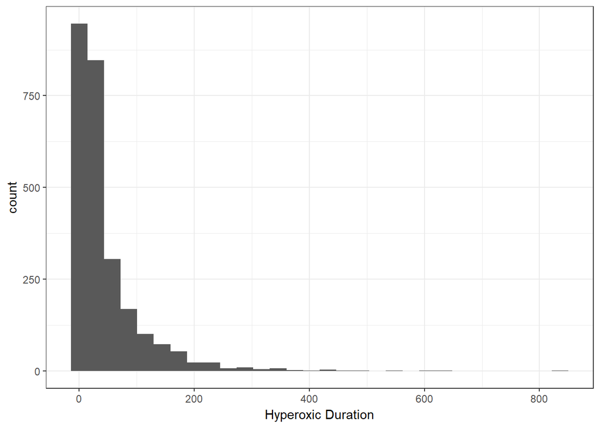

```r
ggplot(hs.eda.df) + geom_histogram(aes(x = hyperoxic_duration)) +
  xlab("Hyperoxic Duration")
```

By group?

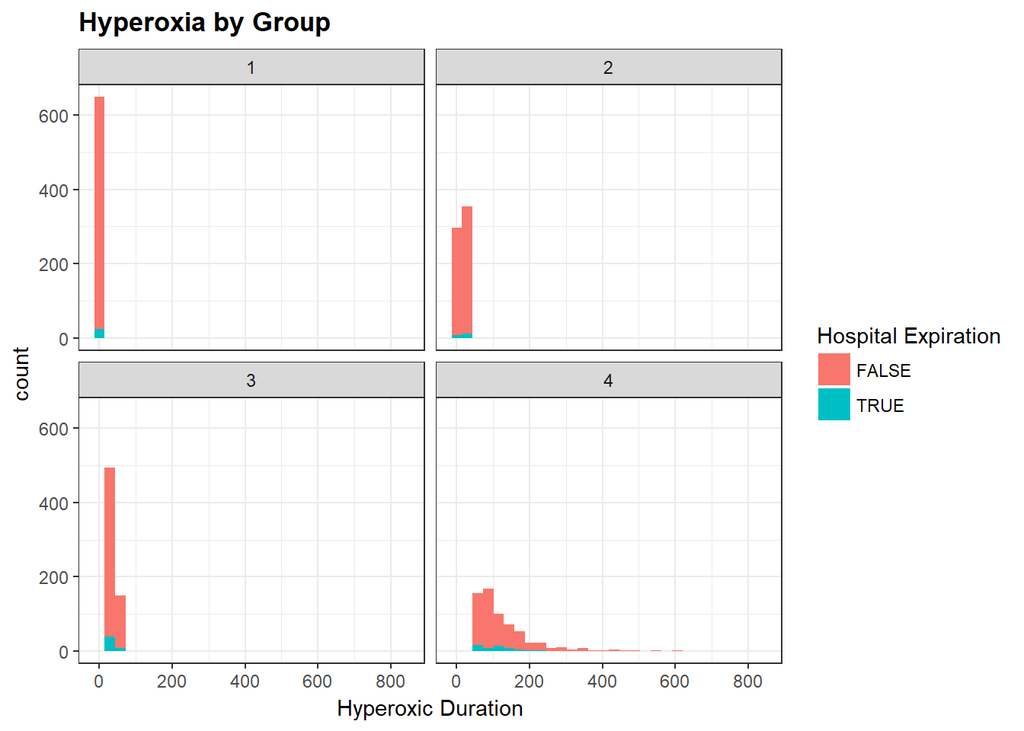

```r
ggplot(hs.eda.df) + geom_histogram(aes(x = hyperoxic_duration, fill = hospital_expire)) +
  facet_wrap(~hyperoxic_group) + xlab("Hyperoxic Duration") +
  guides(fill = guide_legend(title="Hospital Expiration")) + ggtitle("Hyperoxia by Group")
```

Distribution of vent durations?

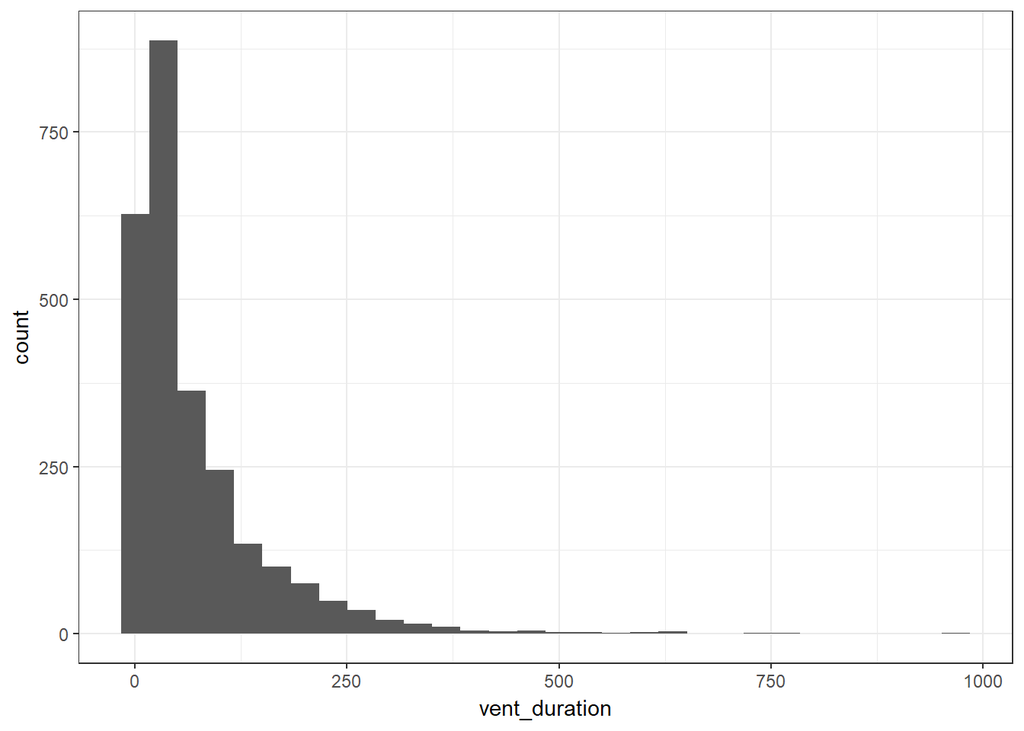

```r
ggplot(hs.eda.df) + geom_histogram(aes(x = vent_duration))
```

Distribution of LOS?

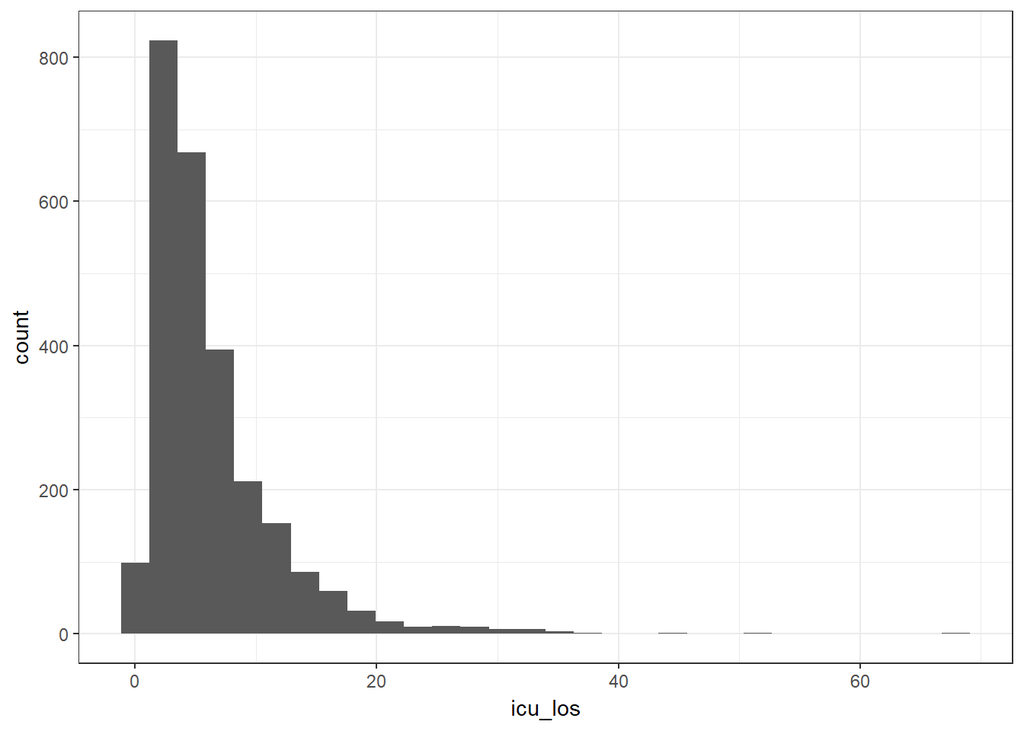

```r
ggplot(hs.eda.df) + geom_histogram(aes(x = icu_los))
```

Association between these?

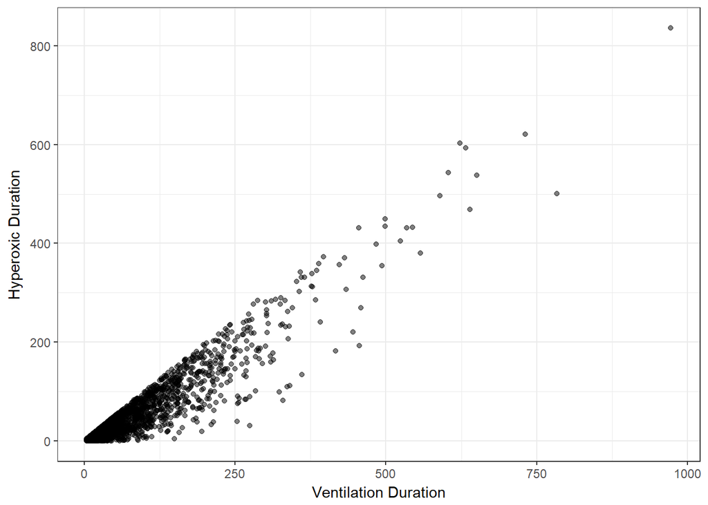

```r
ggplot(hs.eda.df) +
  geom_point(aes(x = vent_duration, y = hyperoxic_duration), alpha = 0.5) +
  xlab("Ventilation Duration") + ylab("Hyperoxic Duration")
```

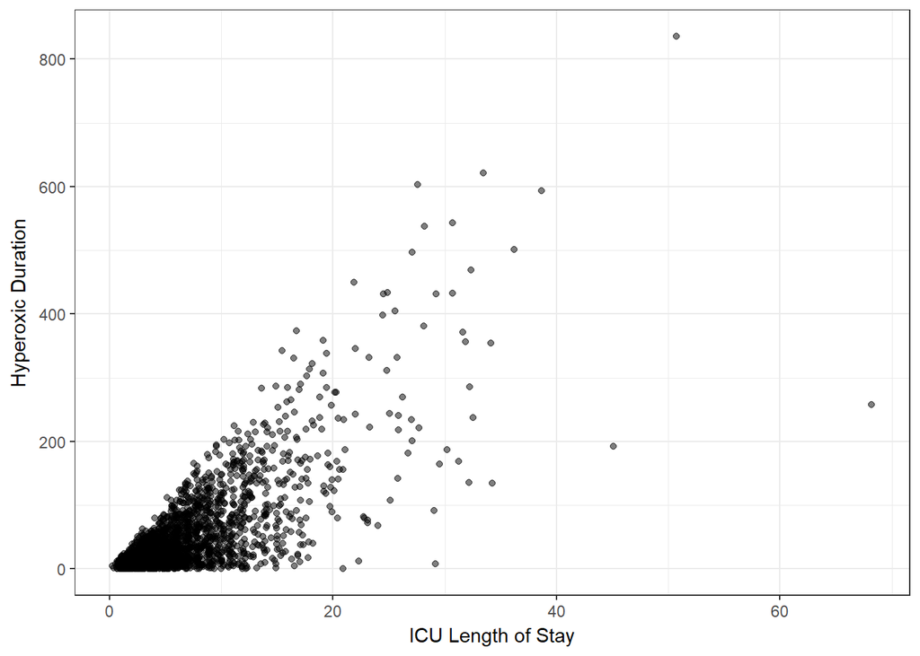

```r
ggplot(hs.eda.df) +
  geom_point(aes(x = icu_los, y = hyperoxic_duration), alpha = 0.5) +
  xlab("ICU Length of Stay") + ylab("Hyperoxic Duration")
```

Is there a clear association with death here?

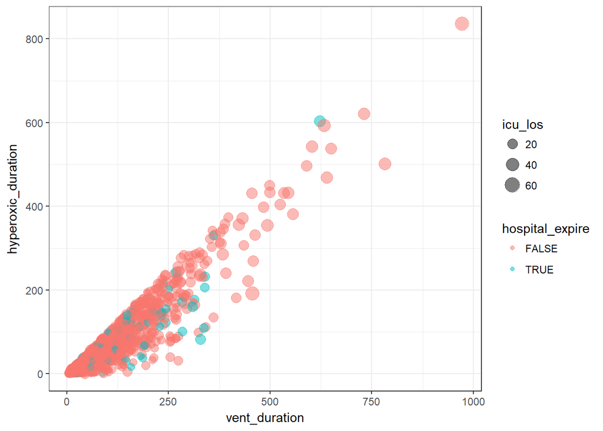

```r
ggplot(hs.eda.df) + geom_point(aes(x = vent_duration, y = hyperoxic_duration, size = icu_los, color = hospital_expire), alpha = 0.5)
```

How does hyperoxic duration correlate with OASIS and Elixhauser? Any pattern for death?

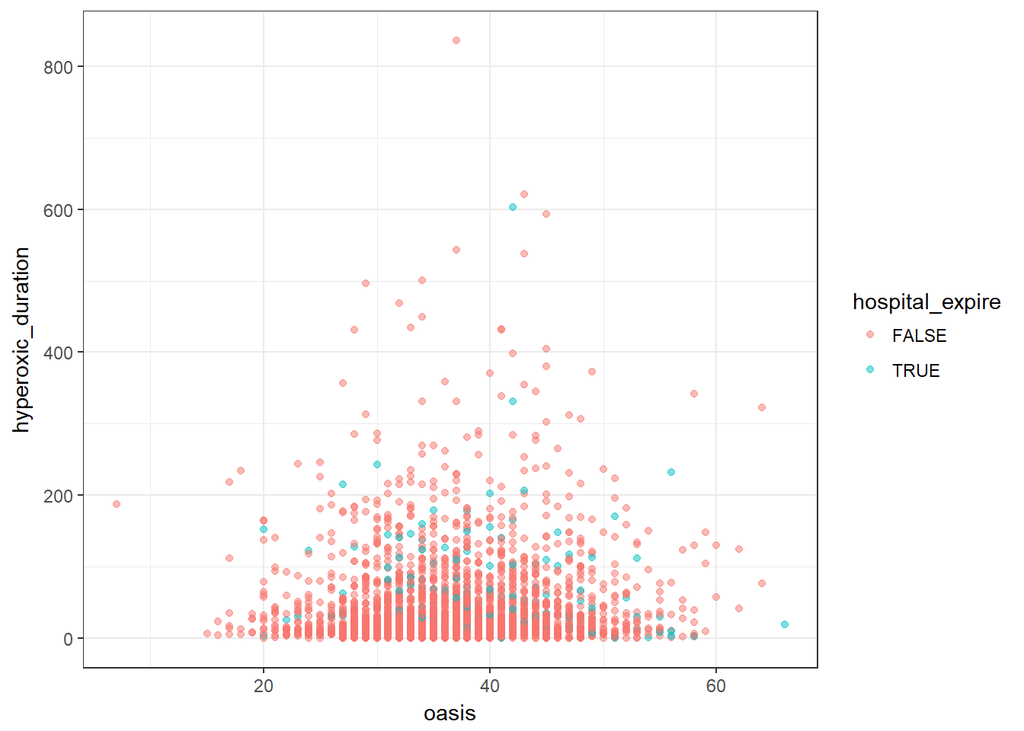

```r
ggplot(hs.eda.df) + geom_point(aes(x = oasis, y = hyperoxic_duration, color = hospital_expire), alpha = 0.5)
```

Age association?

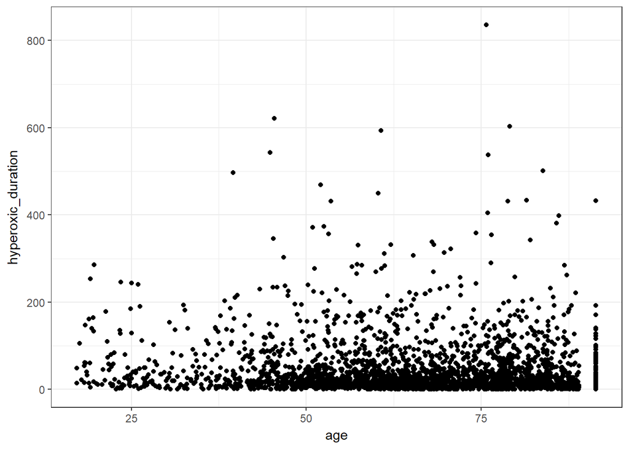

```r
ggplot(hs.eda.df) + geom_point(aes(x = age, y = hyperoxic_duration))
```

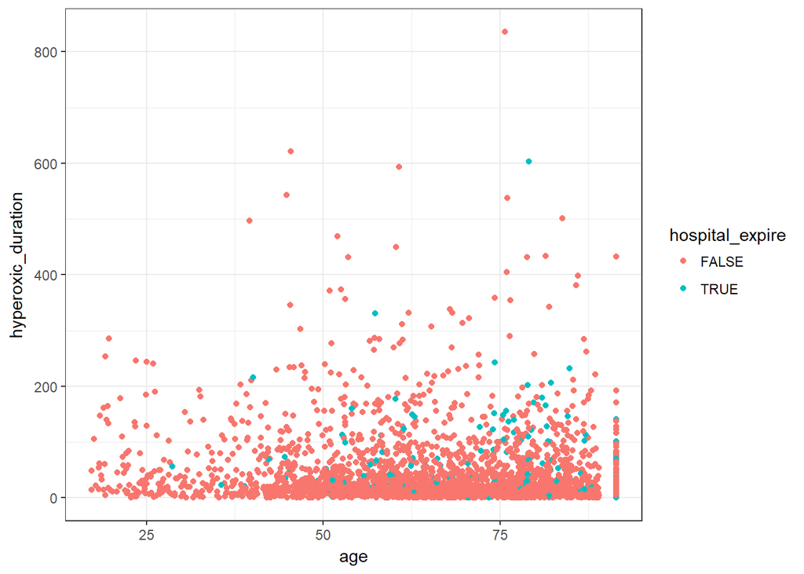

```r
ggplot(hs.eda.df) + geom_point(aes(x = age, y = hyperoxic_duration, color = hospital_expire))
```

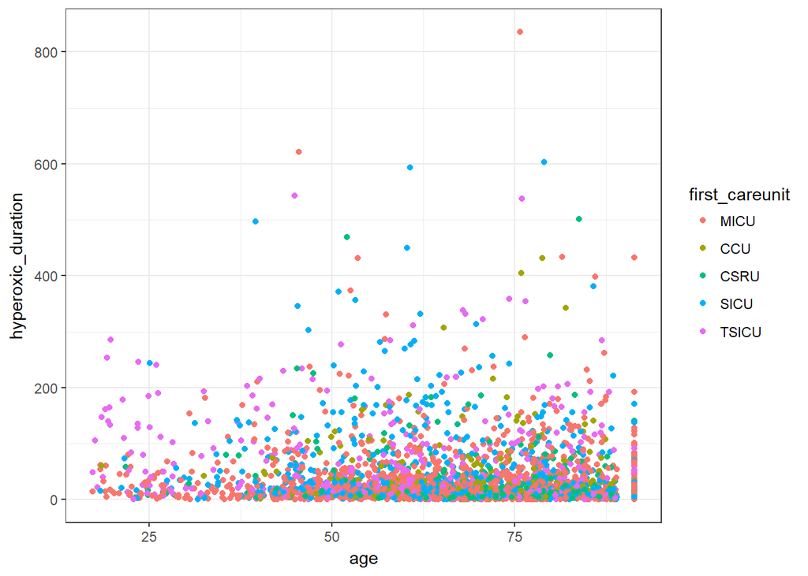

```r
ggplot(hs.eda.df) + geom_point(aes(x = age, y = hyperoxic_duration, color = first_careunit))
```

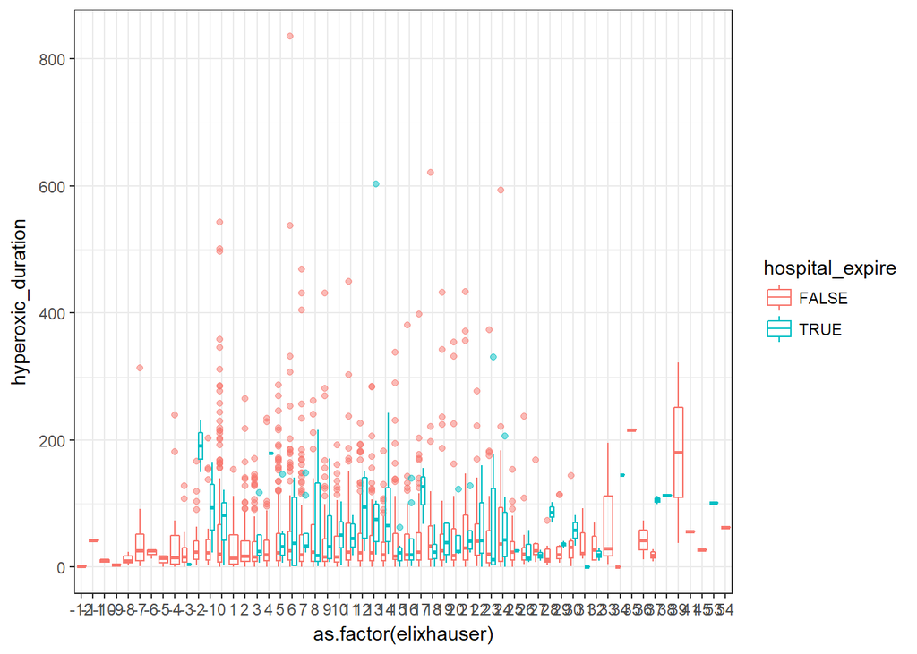

```r
ggplot(hs.eda.df) + geom_boxplot(aes(x = as.factor(elixhauser), y = hyperoxic_duration, color = hospital_expire), alpha = 0.5)
```

How do the above distributions change by our factor variables?

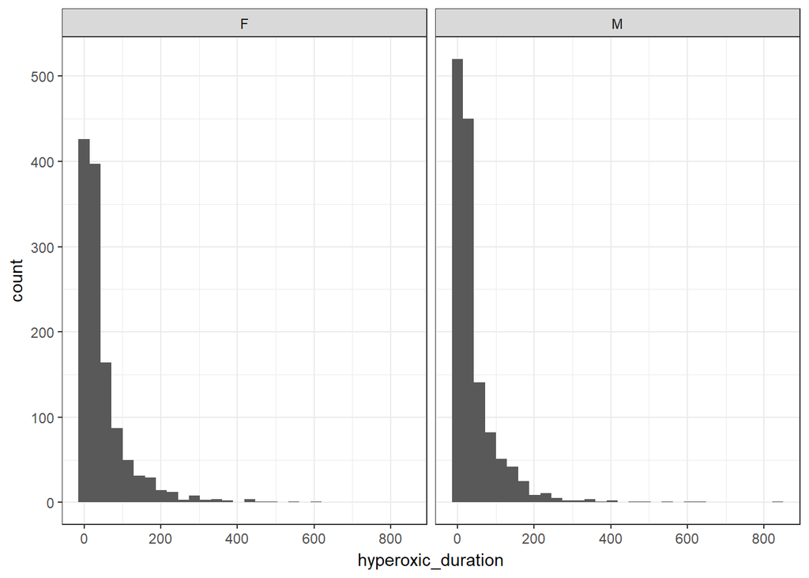

```r
ggplot(hs.eda.df) + geom_histogram(aes(x = hyperoxic_duration)) + facet_wrap(~gender)
```

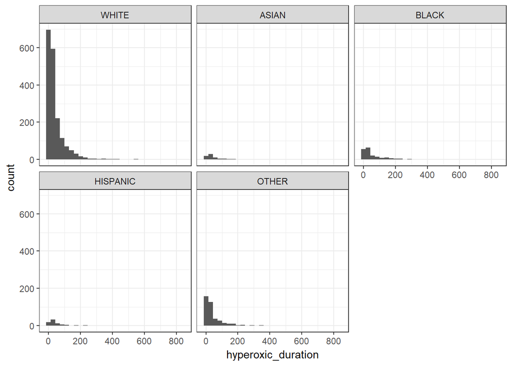

```r
ggplot(hs.eda.df) + geom_histogram(aes(x = hyperoxic_duration)) + facet_wrap(~ethnicity)
```

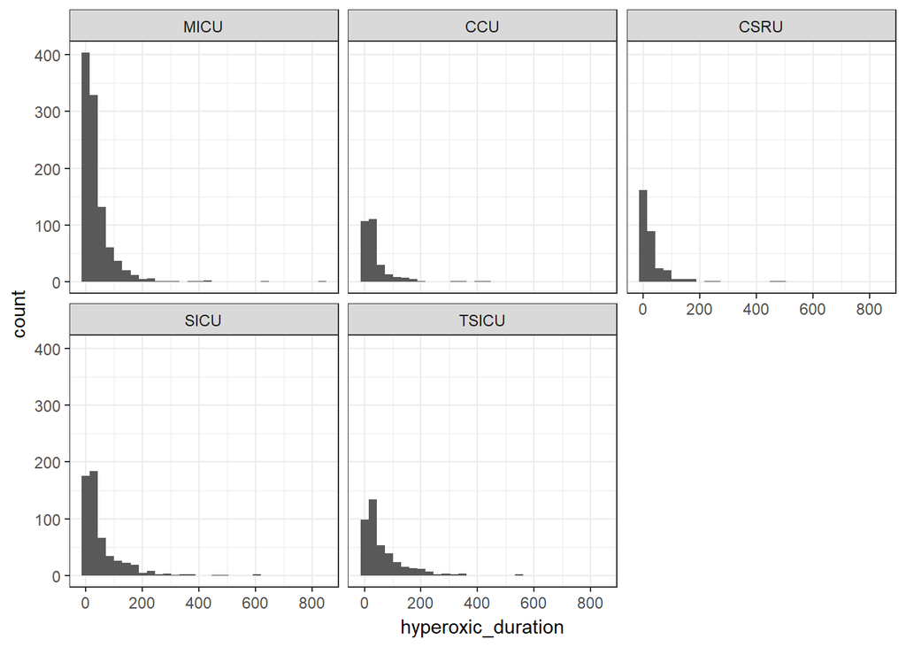

```r
ggplot(hs.eda.df) + geom_histogram(aes(x = hyperoxic_duration)) + facet_wrap(~first_careunit)
```

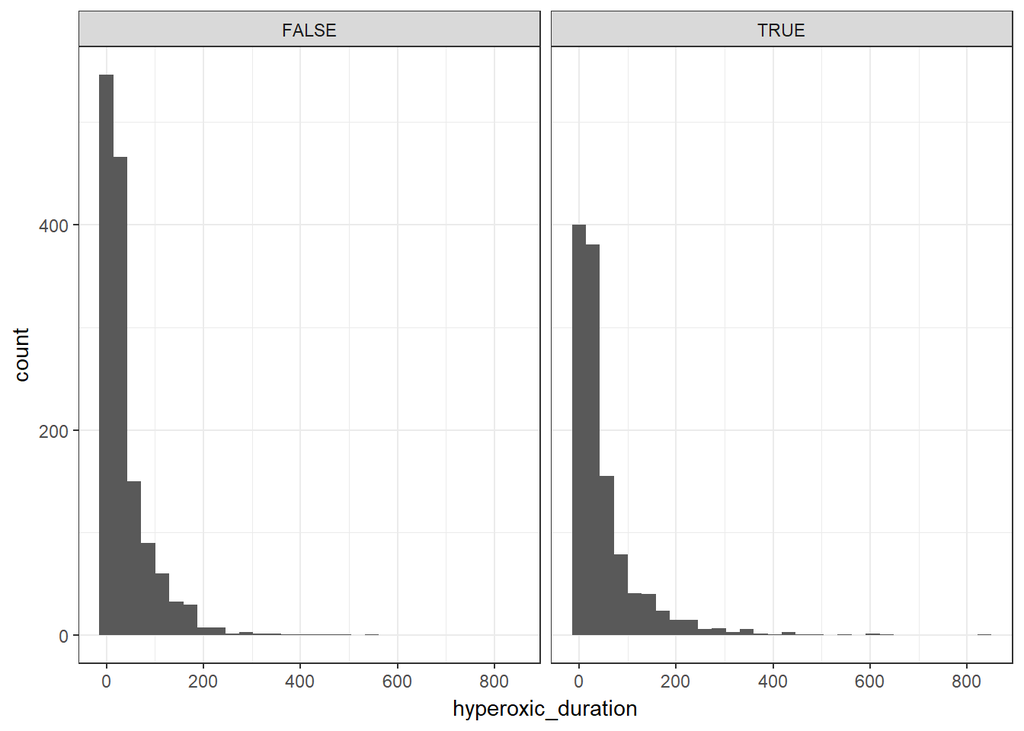

```r
ggplot(hs.eda.df) + geom_histogram(aes(x = hyperoxic_duration)) + facet_wrap(~vasopressor_flag)
```

Since we categorized, I also want to see some of these features across the hyperoxic groups

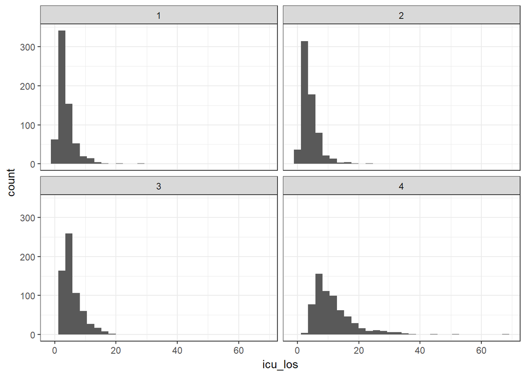

```r
ggplot(hs.eda.df) + geom_histogram(aes(x = icu_los)) + facet_wrap(~hyperoxic_group)
```

Outcome, outcome by group plots

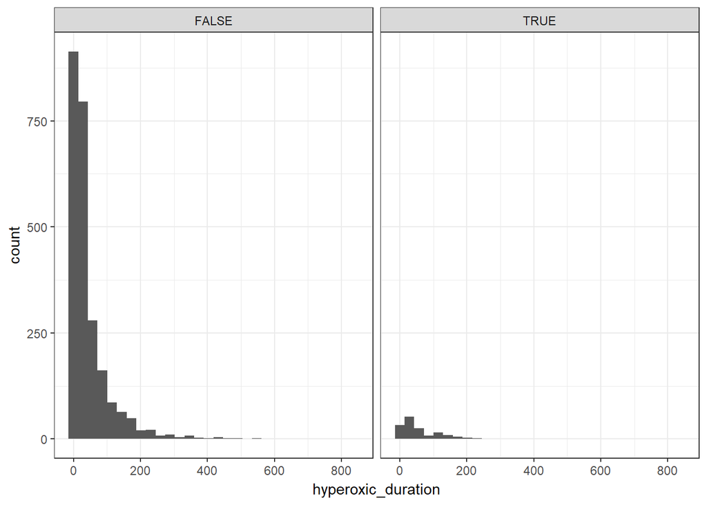

```r
ggplot(hs.eda.df) + geom_histogram(aes(x = hyperoxic_duration)) + facet_wrap(~hospital_expire)
```

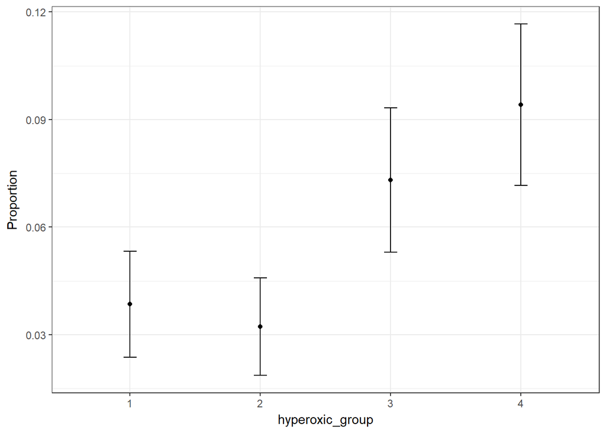

```r
plot_prop_by_level(hs.eda.df %>% mutate(hospital_expire = as.numeric(.$hospital_expire == TRUE)), "hyperoxic_group", "hospital_expire")
```

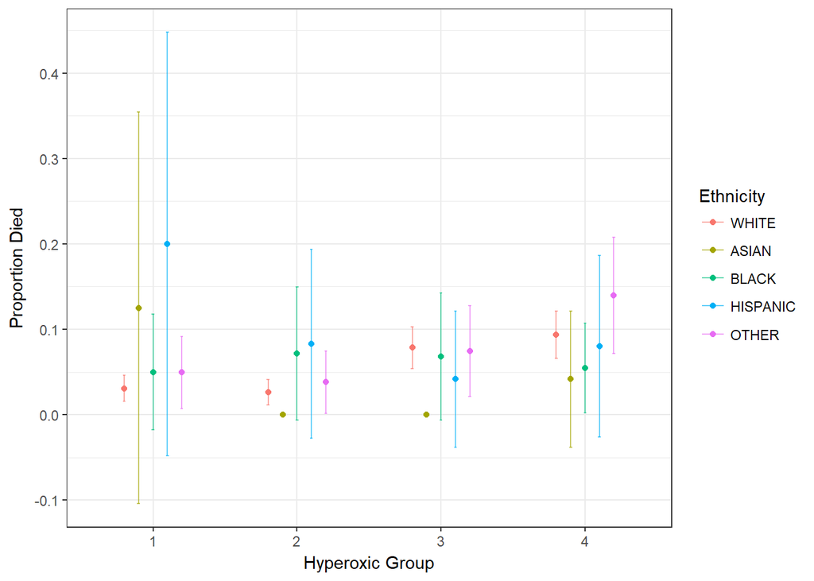

```r
plot_prop_by_level(hs.eda.df %>% mutate(hospital_expire = as.numeric(.$hospital_expire == TRUE)),
                   "hyperoxic_group", "hospital_expire", factor.var2 = "ethnicity") +
  xlab("Hyperoxic Group") + ylab("Proportion Died") +
  guides(color = guide_legend(title="Ethnicity"))
```

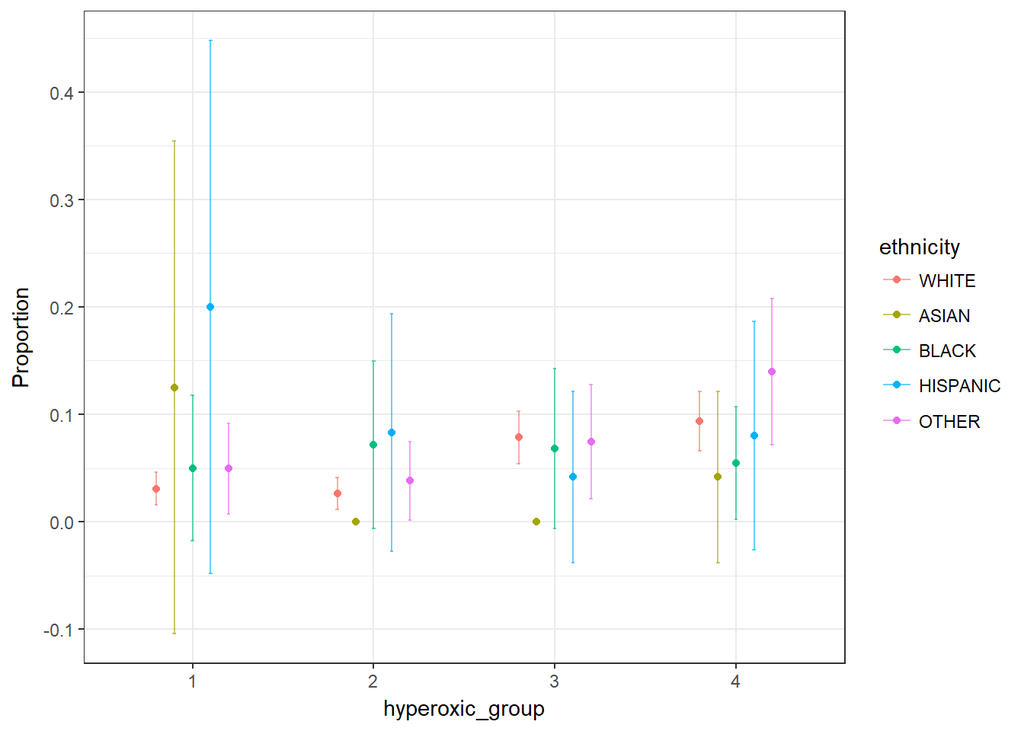

```r
plot_prop_by_level(hs.eda.df %>% mutate(hospital_expire = as.numeric(.$hospital_expire == TRUE)), "hyperoxic_group", "hospital_expire", factor.var2 = "ethnicity")
```

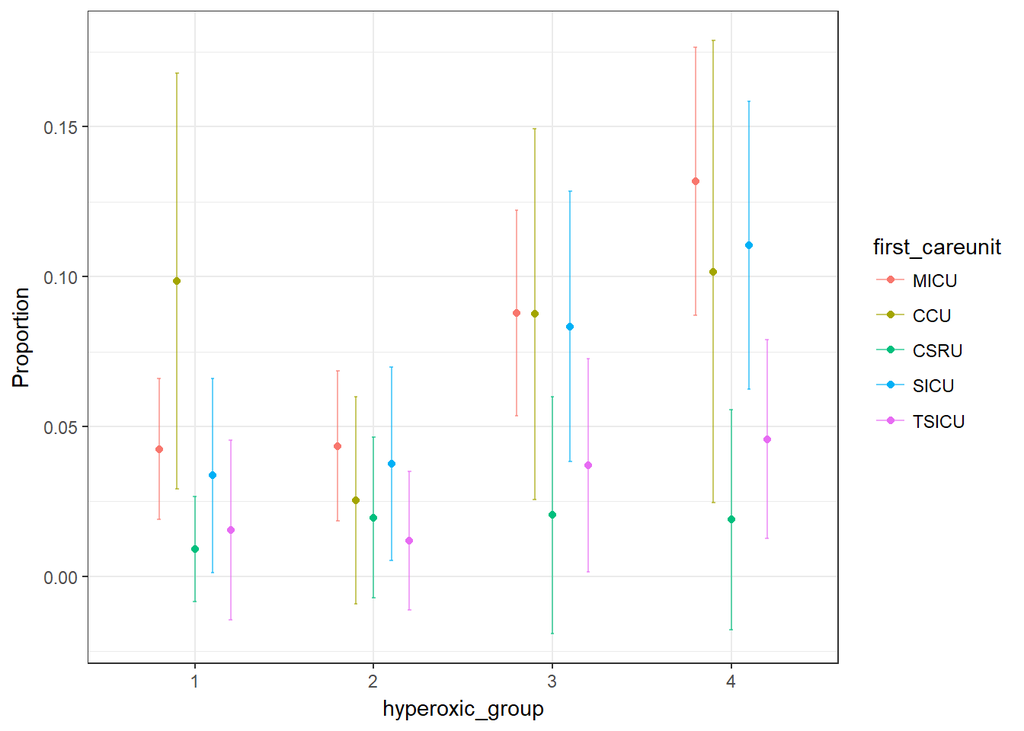

```r
plot_prop_by_level(hs.eda.df %>% mutate(hospital_expire = as.numeric(.$hospital_expire == TRUE)),
                   "hyperoxic_group", "hospital_expire", factor.var2 = "first_careunit")
```

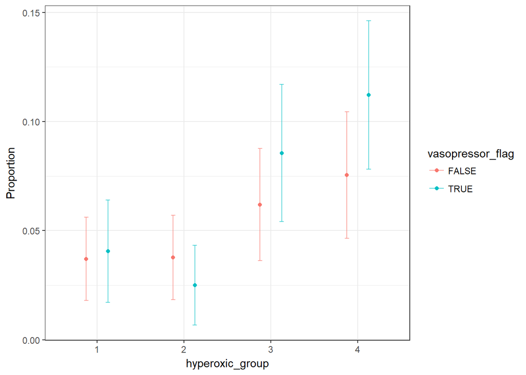

```r
plot_prop_by_level(hs.eda.df %>% mutate(hospital_expire = as.numeric(.$hospital_expire == TRUE)),
                   "hyperoxic_group", "hospital_expire", factor.var2 = "vasopressor_flag")
```

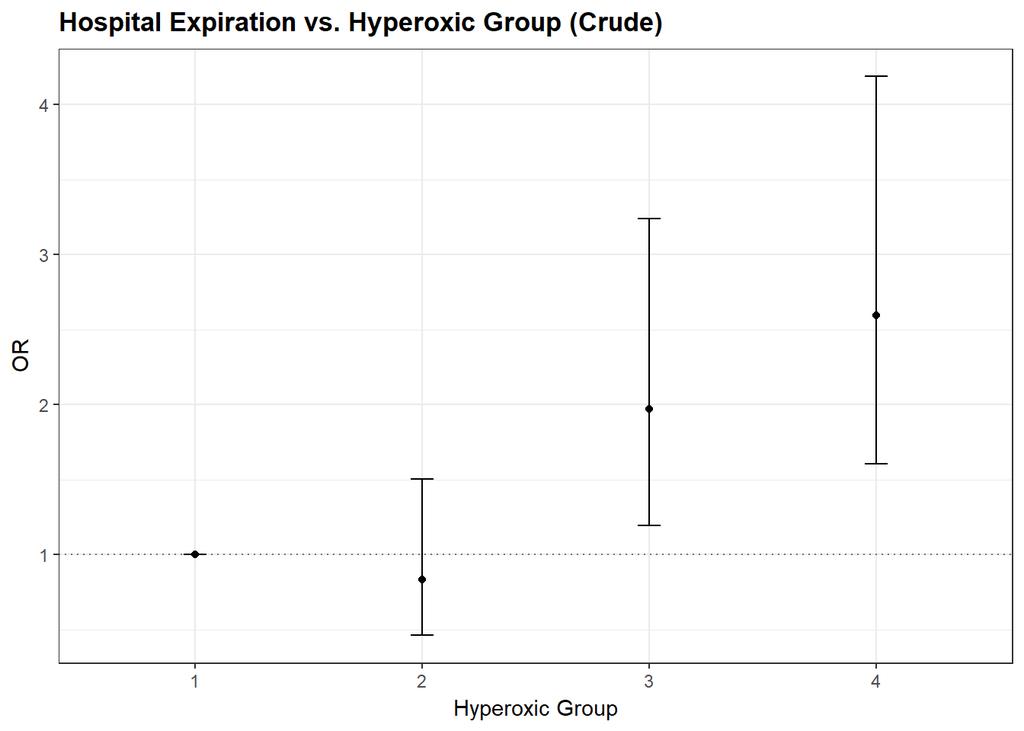

```r
plot_OR_by_level(hs.eda.df %>% mutate(hospital_expire = as.numeric(.$hospital_expire == TRUE)),
                 "hyperoxic_group", "hospital_expire") +
  ggtitle("Hospital Expiration vs. Hyperoxic Group (Crude)") + xlab("Hyperoxic Group")
```

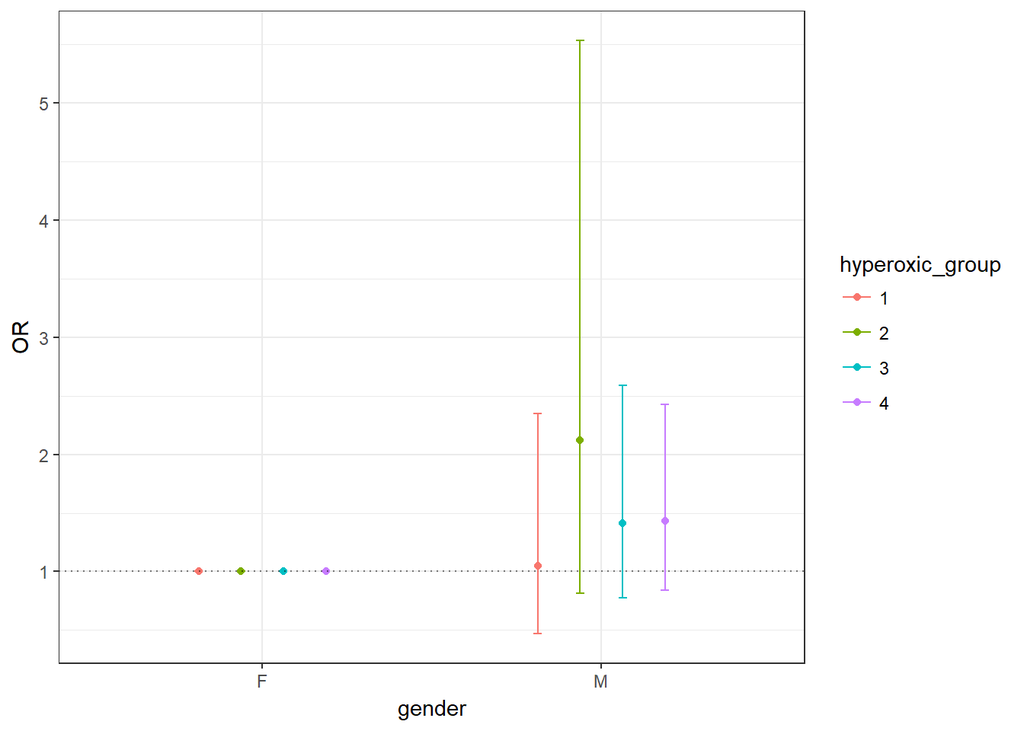

```r
plot_OR_by_level(hs.eda.df %>% mutate(hospital_expire = as.numeric(.$hospital_expire == TRUE)), "hyperoxic_group", "hospital_expire", factor.var2 = "gender")
```

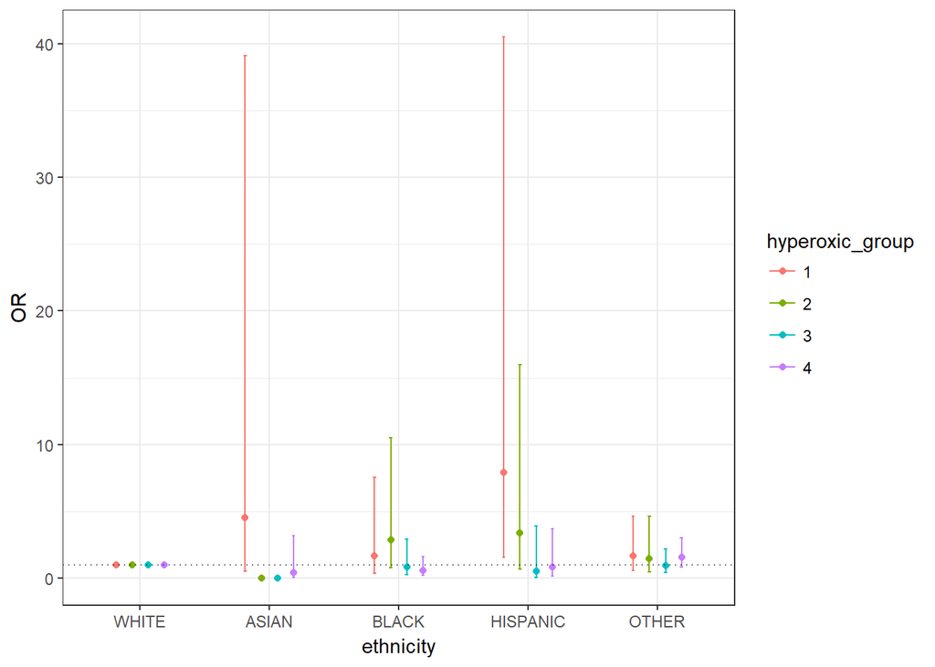

```r
plot_OR_by_level(hs.eda.df %>% mutate(hospital_expire = as.numeric(.$hospital_expire == TRUE)), "hyperoxic_group", "hospital_expire", factor.var2 = "ethnicity")
```

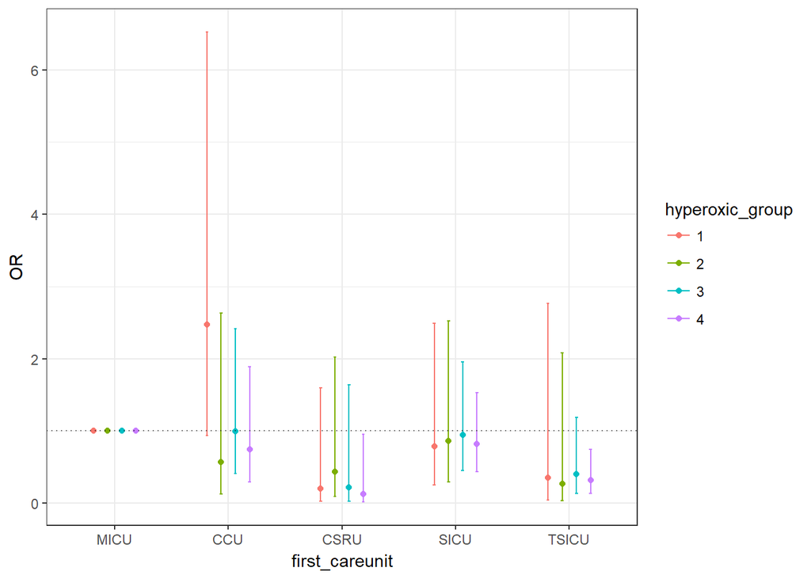

```r
plot_OR_by_level(hs.eda.df %>% mutate(hospital_expire = as.numeric(.$hospital_expire == TRUE)), "hyperoxic_group", "hospital_expire", factor.var2 = "first_careunit")
```

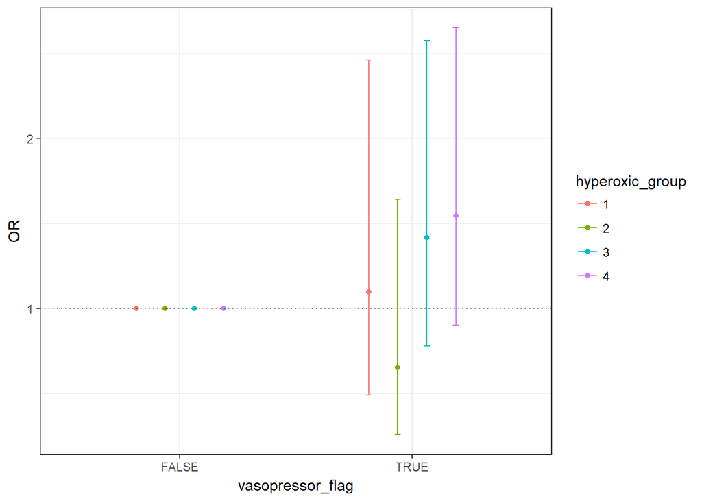

```r
plot_OR_by_level(hs.eda.df %>% mutate(hospital_expire = as.numeric(.$hospital_expire == TRUE)), "hyperoxic_group", "hospital_expire", factor.var2 = "vasopressor_flag")
```

## Modeling inference

```r
crude_model <- glm(hospital_expire ~ hyperoxic_group, family = binomial(link = "logit"),
                      data = hs.eda.df)
summary(crude_model)
```

```
##
## Call:
## glm(formula = hospital_expire ~ hyperoxic_group, family = binomial(link = "logit"),
##     data = hs.eda.df)
##
## Deviance Residuals:
##     Min       1Q   Median       3Q      Max
## -0.4447  -0.3896  -0.2803  -0.2561   2.6207
##
## Coefficients:
##                  Estimate Std. Error z value Pr(>|z|)
## (Intercept)       -3.2173     0.2040 -15.774  < 2e-16 ***
## hyperoxic_group2  -0.1839     0.3013  -0.610  0.54164
## hyperoxic_group3   0.6772     0.2541   2.665  0.00769 **
## hyperoxic_group4   0.9531     0.2443   3.901 9.58e-05 ***
## ---
## Signif. codes:  0 '***' 0.001 '**' 0.01 '*' 0.05 '.' 0.1 ' ' 1
##
## (Dispersion parameter for binomial family taken to be 1)
##
##     Null deviance: 1168.1  on 2590  degrees of freedom
## Residual deviance: 1138.1  on 2587  degrees of freedom
## AIC: 1146.1
##
## Number of Fisher Scoring iterations: 6
```

```r
tidy(crude_model, exponentiate = TRUE, conf.int = TRUE)
```

```
##               term  estimate std.error   statistic      p.value   conf.low
## 1      (Intercept) 0.0400641 0.2039670 -15.7735019 4.734999e-56 0.02616189
## 2 hyperoxic_group2 0.8320000 0.3013450  -0.6103397 5.416368e-01 0.45693948
## 3 hyperoxic_group3 1.9683221 0.2540807   2.6652220 7.693751e-03 1.20726425
## 4 hyperoxic_group4 2.5937990 0.2443350   3.9008891 9.584007e-05 1.62664906
##    conf.high
## 1 0.05839719
## 2 1.50056522
## 3 3.28363829
## 4 4.25670047
```

```r
adj_model <- glm(hospital_expire ~ hyperoxic_group + age + gender +
                        ethnicity + first_careunit + icu_los + vent_duration +
                        oasis + elixhauser + vasopressor_flag, family = binomial(link = "logit"),
                      data = hs.eda.df)
summary(adj_model)
```

```
##
## Call:
## glm(formula = hospital_expire ~ hyperoxic_group + age + gender +
##     ethnicity + first_careunit + icu_los + vent_duration + oasis +
##     elixhauser + vasopressor_flag, family = binomial(link = "logit"),
##     data = hs.eda.df)
##
## Deviance Residuals:
##     Min       1Q   Median       3Q      Max
## -1.8627  -0.3715  -0.2483  -0.1525   3.1386
##
## Coefficients:
##                       Estimate Std. Error z value Pr(>|z|)
## (Intercept)          -6.589456   0.690000  -9.550  < 2e-16 ***
## hyperoxic_group2     -0.172351   0.308676  -0.558  0.57660
## hyperoxic_group3      0.600407   0.266545   2.253  0.02429 *
## hyperoxic_group4      0.863738   0.318280   2.714  0.00665 **
## age                   0.037544   0.006710   5.595  2.2e-08 ***
## genderM               0.555323   0.179894   3.087  0.00202 **
## ethnicityASIAN       -1.323798   0.739275  -1.791  0.07335 .
## ethnicityBLACK       -0.087919   0.330128  -0.266  0.79000
## ethnicityHISPANIC     0.569976   0.430878   1.323  0.18589
## ethnicityOTHER        0.424454   0.229104   1.853  0.06393 .
## first_careunitCCU     0.035018   0.266912   0.131  0.89562
## first_careunitCSRU   -1.433647   0.484713  -2.958  0.00310 **
## first_careunitSICU    0.077182   0.219936   0.351  0.72564
## first_careunitTSICU  -0.735882   0.320079  -2.299  0.02150 *
## icu_los              -0.079945   0.034144  -2.341  0.01921 *
## vent_duration         0.004710   0.001940   2.428  0.01519 *
## oasis                -0.003802   0.012535  -0.303  0.76166
## elixhauser            0.068747   0.010101   6.806  1.0e-11 ***
## vasopressor_flagTRUE  0.144563   0.184245   0.785  0.43267
## ---
## Signif. codes:  0 '***' 0.001 '**' 0.01 '*' 0.05 '.' 0.1 ' ' 1
##
## (Dispersion parameter for binomial family taken to be 1)
##
##     Null deviance: 1168.1  on 2590  degrees of freedom
## Residual deviance: 1001.7  on 2572  degrees of freedom
## AIC: 1039.7
##
## Number of Fisher Scoring iterations: 7
```

```r
tidy(adj_model, exponentiate = TRUE, conf.int = TRUE)
```

```
##                    term    estimate   std.error  statistic      p.value
## 1           (Intercept) 0.001374788 0.689999539 -9.5499420 1.297690e-21
## 2      hyperoxic_group2 0.841684102 0.308676419 -0.5583533 5.766031e-01
## 3      hyperoxic_group3 1.822861042 0.266544699  2.2525575 2.428706e-02
## 4      hyperoxic_group4 2.372010119 0.318280494  2.7137627 6.652379e-03
## 5                   age 1.038257837 0.006710164  5.5951165 2.204737e-08
## 6               genderM 1.742504232 0.179893633  3.0869536 2.022192e-03
## 7        ethnicityASIAN 0.266122628 0.739274941 -1.7906708 7.334613e-02
## 8        ethnicityBLACK 0.915835324 0.330128052 -0.2663170 7.899951e-01
## 9     ethnicityHISPANIC 1.768224153 0.430877988  1.3228240 1.858939e-01
## 10       ethnicityOTHER 1.528756115 0.229104207  1.8526696 6.392972e-02
## 11    first_careunitCCU 1.035638184 0.266912347  0.1311960 8.956202e-01
## 12   first_careunitCSRU 0.238437756 0.484713338 -2.9577213 3.099222e-03
## 13   first_careunitSICU 1.080239012 0.219935703  0.3509313 7.256399e-01
## 14  first_careunitTSICU 0.479082576 0.320078796 -2.2990661 2.150119e-02
```

[output cut: 25 more lines]

*Hoslem Goodness of Fit*

```r
hoslem_gof(adj_model)$p.value
```

```
## [1] 0.5004612
```

### Visualizing the Results

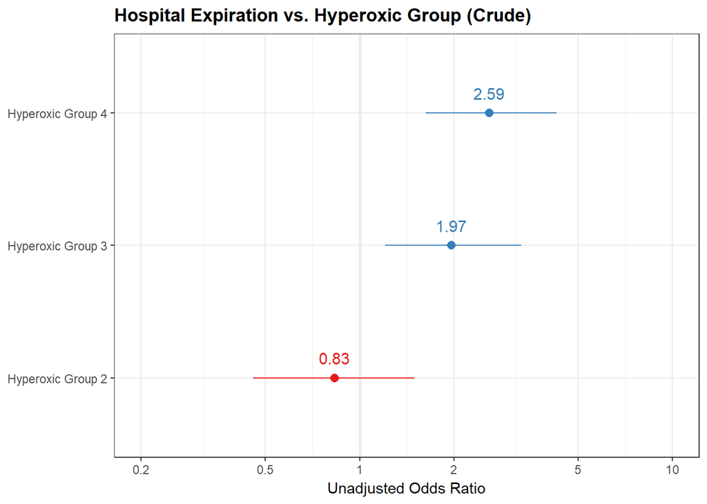

```r
sjPlot::plot_model(crude_model, terms = c("hyperoxic_group4", "hyperoxic_group3", "hyperoxic_group2"),  order.terms = c(3, 2, 1), axis.labels = c("Hyperoxic Group 2", "Hyperoxic Group 3", "Hyperoxic Group 4"), show.values = TRUE, title = "Hospital Expiration vs. Hyperoxic Group (Crude)", show.p = FALSE, axis.title = "Unadjusted Odds Ratio", type = "est")
```

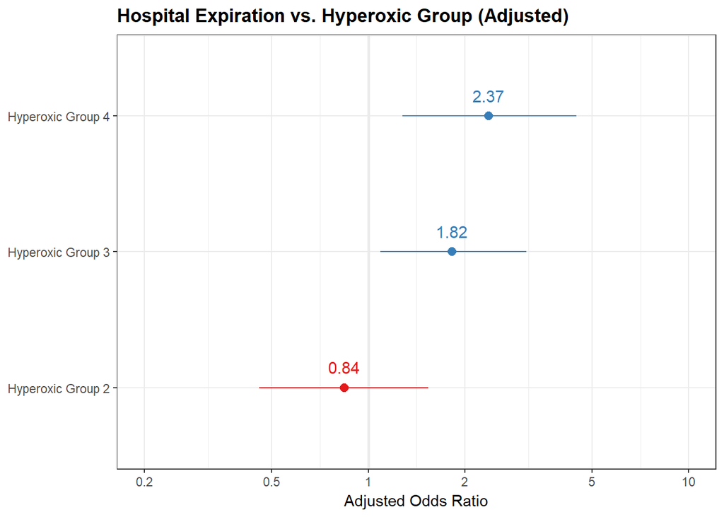

```r
sjPlot::plot_model(adj_model, terms = c("hyperoxic_group4", "hyperoxic_group3", "hyperoxic_group2"),  order.terms = c(3, 2, 1), axis.labels = c("Hyperoxic Group 2", "Hyperoxic Group 3", "Hyperoxic Group 4"), show.values = TRUE, title = "Hospital Expiration vs. Hyperoxic Group (Adjusted)", show.p = FALSE, axis.title = "Adjusted Odds Ratio", type = "est")
```